# task 14

Paulius Kostickis

Tuesday, May 03, 2016

#### 1. Choose one of the following seasonal time series: condmilk, hsales, uselec

Pasirinksime condmilk duomenis - kondensuoto pieno gamintojo akcijas.

#### (a) Do the data need transforming? If so, find a suitable transformation.

Matome, jog duomenims nebūtina transformacija, variacija atrodo vienoda visu laiku.

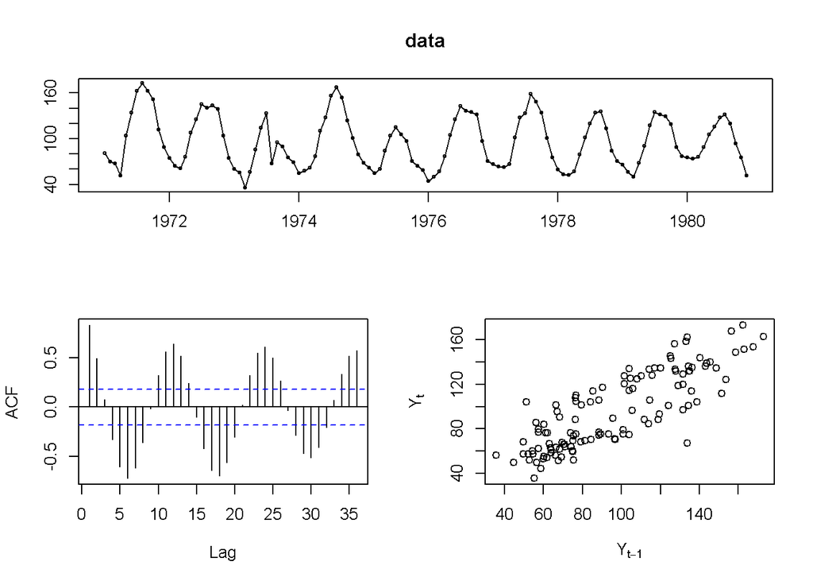

```r
data=condmilk
tsdisplay(data, plot.type="scatter")
```

#### (b) Are the data stationary? If not, find an appropriate differencing, which yields stationary data.

Kadangi duomenys turi sezoniškumą, reikia diferencijuoti, kad gauti stacionarius duomenis:

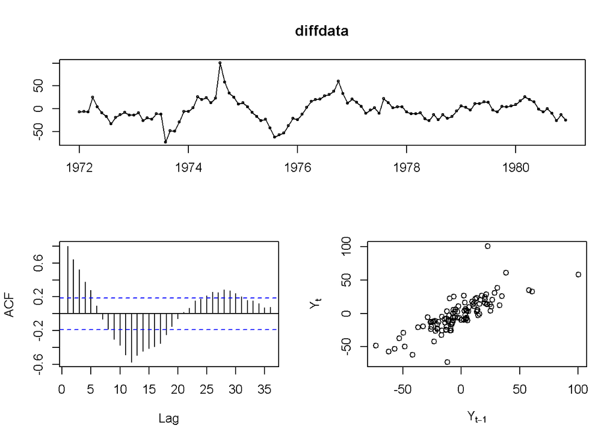

```r
diffdata<-diff(condmilk, lag=12)
tsdisplay(diffdata, plot.type="scatter")
```

Vis dar nėra stacionarūs duomenys, tai diferencijuojame dar kartą:

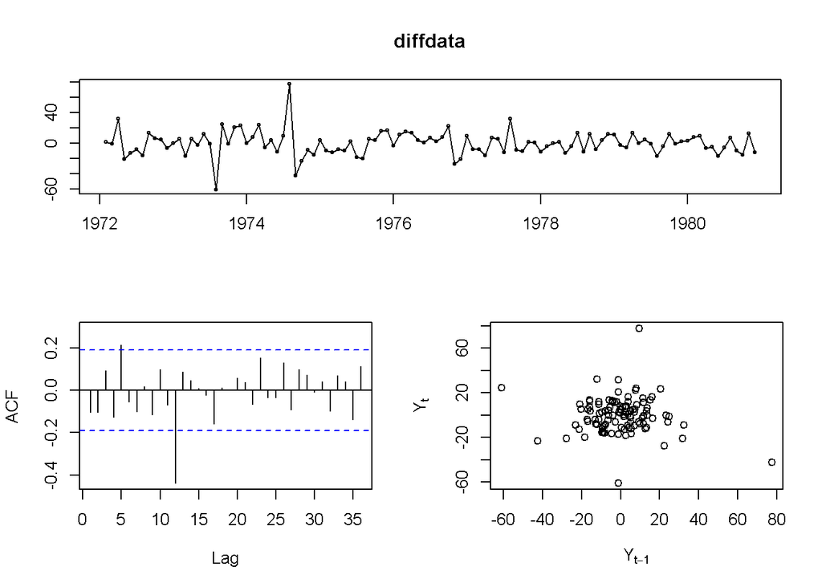

```r
diffdata<-diff(diffdata, lag=1)
tsdisplay(diffdata, plot.type="scatter")
```

Dabar duomenys yra stacionarūs.

3. Identify a couple of ARIMA models that might be useful in describing the time series. Which of your models is the best according to their AIC values?

Pirma pažiūrėsime į ACF ir PACF grafikus:

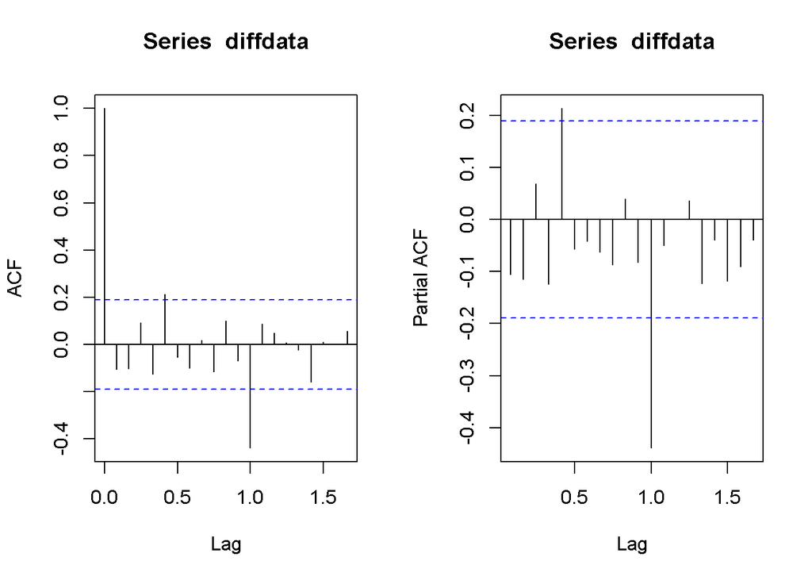

```r
par(mfrow=c(1,2))
acf(diffdata)
pacf(diffdata)
```

Iš grafikų galime bandyti sudaryti **ARIMA(0,1,1)(2,1,0)[12]** ir truputį jį modifikuoti pabandymui:

```r
mod0=arima(data, order = c(0,1,1),seasonal = list(order=c(2,1,0),period=12))
mod1=auto.arima(data)
mod2=arima(data, order = c(1,1,1),seasonal = list(order=c(2,1,2),period=12))
```

Kaip matome paskutinio modelio AIC geriausias:

```r
modeliai <-c(1,2,3)
aic <- c(AIC(mod0), AIC(mod1), AIC(mod2))
data.frame(modeliai, aic)
```

```
##   modeliai      aic
## 1        1 856.2105
## 2        2 973.1526
## 3        3 852.4096
```

Tai geriausias modelis pagal AIC yra **ARIMA(1,1,1)(2,1,2)[12]**

4. Estimate the parameters of your best model and do diagnostic testing on the residuals. Do the residuals resemble white noise? If not, try to find another ARIMA model which fits better.

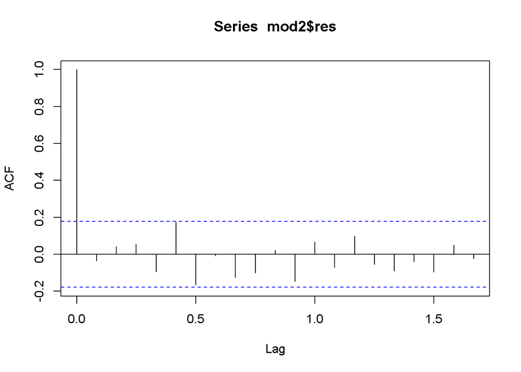

```r
acf(mod2$res)
```

```r
Box.test(mod2$res, type="Lj") #p-value>0.05, vadinasi liekanos yra baltasis triukšmas
```

```
##
##  Box-Ljung test
##
## data:  mod2$res
## X-squared = 0.1601, df = 1, p-value = 0.689
```

**ARIMA(1,1,1)(2,1,2)[12]** modelio paklaido yra baltasis triukšmas, reiškia galime pasirinkti šį modelį.

5. Forecast the next 24 months of data using your preferred model.

**ARIMA(1,1,1)(2,1,2)[12]** prognozė:

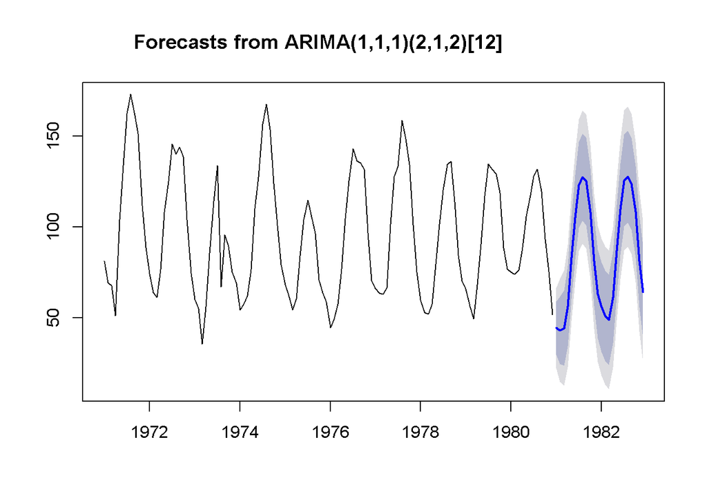

```r
prognoze<- forecast(mod2, h=24)
plot(prognoze)
```

Atrodo logiška.

6. Compare the forecasts obtained using ets().

Gauname ETS(M,N,M):

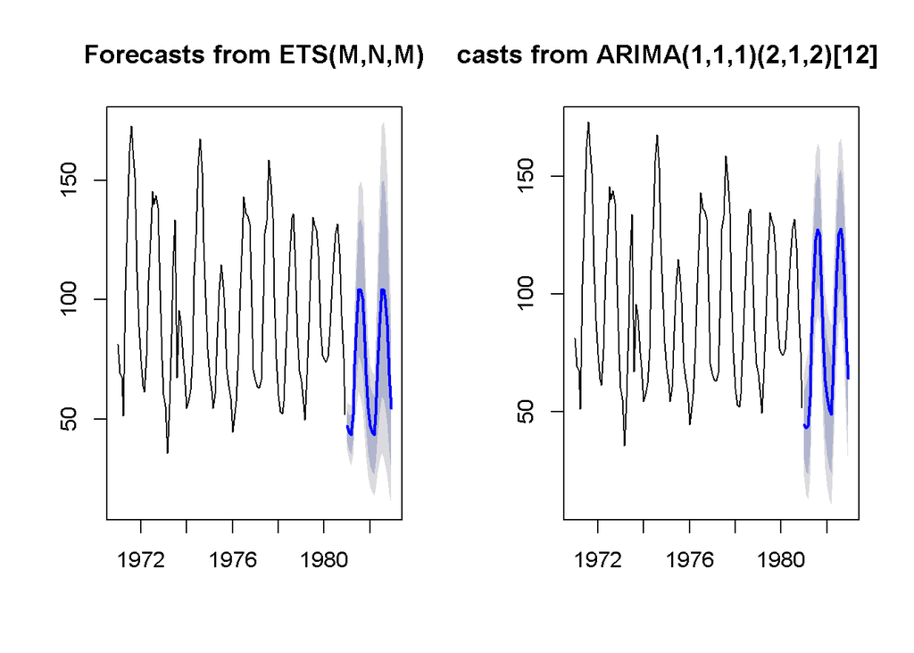

```r
modETS <- ets(data)
prognoze_ETS <- forecast(modETS, h=24)
par(mfrow=c(1,2))
plot(prognoze_ETS)
plot(prognoze)
```

Iš akies žiūrint atrodo, jog ARIMA geriau prognozuotų žiūrint į praities duomenis.

Palyginsime juos pagal AIC:

```r
modeliai <- c("ARIMA","ETS")
AIC <- c(AIC(mod2), AIC(modETS))
data.frame(modeliai, AIC)
```

```
##   modeliai       AIC
## 1    ARIMA  852.4096
## 2      ETS 1151.6100
```

Matome ARIMA turi mažesnį AIC.